# Advanced Machine Learning Project

### Feature correlations

```python
cols = df_raw.columns.tolist()
cols.index('popularity')
```

```
9
```

```python
cols = df_raw.columns.tolist()
cols.remove('popularity')
cols
```

```
['acousticness',
 'danceability',
 'energy',
 'explicit',
 'instrumentalness',
 'key',
 'liveness',
 'loudness',
 'mode',
 'speechiness',
 'tempo',
 'valence',
 'year',
 'release_Year',
 'release_Month',
 'release_Week',
 'release_Day',
 'release_Dayofweek',
 'release_Dayofyear',
 'release_Is_month_end',
 'release_Is_month_start',
 'release_Is_quarter_end',
 'release_Is_quarter_start',
 'release_Is_year_end',
 'release_Is_year_start',
 'release_Elapsed',
 'duration_min']
```

```python
len(df_raw.columns)
```

```
28
```

```python
import scipy
```

```python
corr = np.round(scipy.stats.spearmanr(df_raw[cols]).correlation, 4)
corr.size
```

```
729
```

[output not shown]

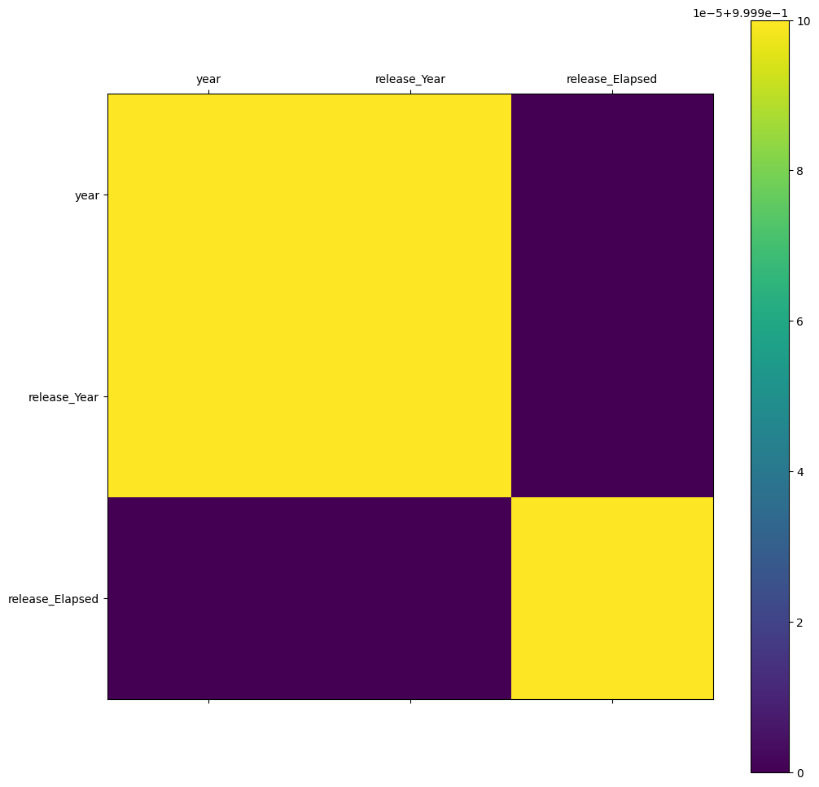

```python
col_small = [
    'year',
    'release_Year',
    'release_Elapsed',
]
corr_small = np.round(scipy.stats.spearmanr(df_raw[col_small]).correlation, 4)
corr_small.size

fig = plt.figure(figsize=(12, 12))
ax = fig.add_subplot(111)
cax = ax.matshow(corr_small)

fig.colorbar(cax)

ax.set_xticklabels([''] + col_small)
ax.set_yticklabels([''] + col_small)
```

```python
corr_condensed = hierarchy.distance.squareform(1 - corr)
corr_condensed.size
```

```
351
```

```python
corr_linkage = hierarchy.linkage(corr_condensed, method = 'average')
```

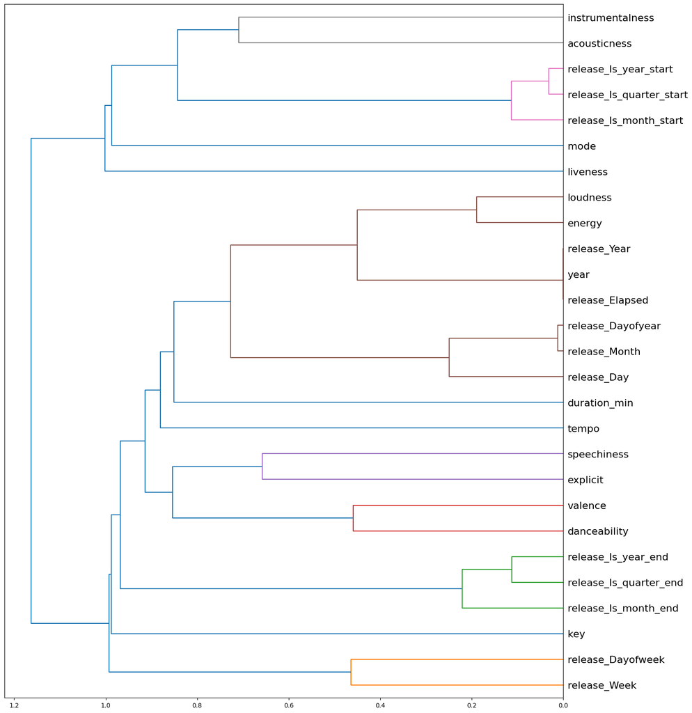

```python
# compute plot
fig = plt.figure(figsize = (16,20))
dendrogram = hierarchy.dendrogram(
    corr_linkage,
    labels = cols,
    orientation = 'left',
    leaf_font_size = 16,
)
plt.show()
```

```python
from collections import defaultdict
```

```python
# compute hierarchical clustering
threshold = 0.1
cluster_ids = hierarchy.fcluster(corr_linkage, threshold, criterion = 'distance')
```

```python
cluster_ids
```

```
array([20,  6, 13,  8, 21, 17, 23, 14, 22,  9, 16,  7, 12, 12, 10,  1, 11,
        2, 10,  5, 19,  3, 18,  4, 18, 12, 15], dtype=int32)
```

```python
# reshape clustering as {cluster_index : feature_index}
cluster_id_to_feature_ids = defaultdict(list)
for idx, cluster_id in enumerate(cluster_ids):
    cluster_id_to_feature_ids[cluster_id].append(idx)
```

```python
cluster_id_to_feature_ids
```

```
defaultdict(list,
            {20: [0],
             6: [1],
             13: [2],
             8: [3],
             21: [4],
             17: [5],
             23: [6],
             14: [7],
             22: [8],
             9: [9],
             16: [10],
             7: [11],
             12: [12, 13, 25],
             10: [14, 18],
             1: [15],
             11: [16],
             2: [17],
             5: [19],
             19: [20],
             3: [21],
             18: [22, 24],
             4: [23],
             15: [26]})
```

```python
# keep only first feature for each cluster
selected_features = [v[0] for v in cluster_id_to_feature_ids.values()]

# shift feature index after 62
selected_features = [(i if i < 62 else i+1) for i in selected_features]
```

```python
# retained set of features
selected_features = [df.columns[i] for i in selected_features]
selected_features
```

```
['acousticness',
 'danceability',
 'energy',
 'explicit',
 'instrumentalness',
 'key',
 'liveness',
 'loudness',
 'mode',
 'speechiness',
 'tempo',
 'valence',
 'year',
 'release_Month',
 'release_Week',
 'release_Day',
 'release_Dayofweek',
 'release_Is_month_end',
 'release_Is_month_start',
 'release_Is_quarter_end',
 'release_Is_quarter_start',
 'release_Is_year_end',
 'duration_min']
```

### Perform training on ablated set of features

```python
df_keep = df[selected_features].copy()

n_total = len(df_keep)
n_valid = 51000
n_train = n_total - n_valid
n_small = 20000

X_train_keep, X_valid_keep = split_vals(df_keep, n_train)
y_train, y_valid = split_vals(y, n_train)

X_small_keep, _ = split_vals(df_keep, n_small)
y_small, _ = split_vals(y, n_small)

print('Number of small training data points: X = {}, y = {}'.format(X_small.shape, y_small.shape))
print('Number of full training data points: X = {}, y = {}'.format(X_train.shape, y_train.shape))
print('Number of validation data points: X = {}, y = {}'.format(X_valid.shape, y_valid.shape))
```

```
Number of small training data points: X = (20000, 27), y = (20000,)
Number of full training data points: X = (118909, 27), y = (118909,)
Number of validation data points: X = (51000, 27), y = (51000,)
```

```python
best_model2 = RandomForestRegressor(
    n_estimators = 35,
    criterion = 'squared_error',

    # stoping criteria
    max_depth = 8,
    min_samples_split = 2,
    min_samples_leaf = 2,
    min_weight_fraction_leaf = 0.0,
    max_leaf_nodes = None,
    min_impurity_decrease = 0.0,
    ccp_alpha = 0.0,

    # bagging parameters
    max_features = 0.3,
    bootstrap = True,
    oob_score = True,
    max_samples = 0.75,

    # other
    warm_start = False,
    n_jobs = -1, # None
    random_state = 42, # None,
    verbose = 0,
)

%time best_model2.fit(X_train_keep, y_train)
print_score(best_model2, X_train_keep, y_train, X_valid_keep, y_valid)
```

```
CPU times: total: 7.31 s
Wall time: 1.79 s
RMSE on train set: 10.3381
RMSE on valid set: 6.3370
R^2 on train set: 0.7752
R^2 on valid set: 0.9093
R^2 on oob set: 0.7686
```

### Permutation of feature importance after feature selection

```python
result = permutation_importance(
    best_model2,
    X_valid_keep,
    y_valid,
    n_repeats = 5,
    random_state = 42,
    n_jobs = -1,
)
sorted_idx = result.importances_mean.argsort()
```

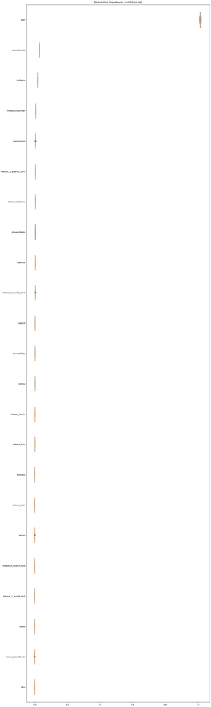

```python
fig, ax = plt.subplots(figsize = (15, 50))
ax.boxplot(
    result.importances[sorted_idx].T,
    vert = False,
    labels = X_valid.columns[sorted_idx],
)
ax.set_title("Permutation Importances (validation set)")
fig.tight_layout()
plt.show()
```

### Saving model

```python
path_to_saves = os.path.join(path_to_repo, 'saves')
print(path_to_saves)

if not os.path.isdir(path_to_saves):
    os.mkdir(path_to_saves)
    print(path_to_saves, 'was created')
else:
    print(path_to_saves, 'already exists')
```

```
C:\Users\Natha\emlyon-dsaib\Advanced Machine Learning\EMLyon-ML-Course-2022-T1-main\saves
C:\Users\Natha\emlyon-dsaib\Advanced Machine Learning\EMLyon-ML-Course-2022-T1-main\saves already exists
```

```python
# save model on disk
path_to_model = os.path.join(path_to_repo, 'saves', 'RF_regressor.pk')
with open(path_to_model, 'wb') as file:
    dill.dump(best_model2, file)
```

# Conclusion:

#### Final Model:

In this project, we tested several parameters, using Grid Search and understanding our feature importance/ correlation to improve our final Random Forest Regressor model.

The OOB score (0.7686) is not significantly lower than the R^2 on our training set (0.7752) which is another good indication that our model is not overfitting.

#### How we would further improve our project:

- Using Boosting algorithms such as CatBoost and XBoost, to find a more accurate model
- Understanding feature importance, permutation importance and feature correlation in more depth, in order to see how we can use the information we got to further understand our dataset and find out how to improve our model
- Since we realised a lot of our features were not relevant enough to predict the popularity of a song, we could potentially add new features to our dataset, that provide more details of a song, that could be more relavant than our existing features
- We would perform the Grid Search with more values. Since the Grid Search takes a long time to run, if we had more time for this project, we would be able to get better optimal combination of parameters
- Testing out more paramemters with the Bagging model - our bagging model gave us decent results, however need more time and more processing power
- Spend more time understanding overfitting, to be able to properly identify when our model is overfitting, and how to properly overcome this problem
- Test our best model on a new dataset of songs, to see how accurately it performs